# Client Report -How good is it, really?

- Show All Code
- Hide All Code

Unit 4 Task 2

Author

John Wendt

```python
import polars as pl
import numpy as np
from lets_plot import *
from sklearn.model_selection import train_test_split
from sklearn import metrics
from sklearn.ensemble import RandomForestClassifier
# add the additional libraries you need to import for ML here

LetsPlot.setup_html(isolated_frame=True)
```

```python
df = pl.read_csv("dwellings_ml.csv")
X_train, X_test, y_train, y_test = train_test_split(
  df.select(["arcstyle_ONE-STORY","gartype_Att","quality_C","livearea","finbsmnt","numbaths"]),
  df["before1980"],
  test_size=0.09,
  random_state=0
)
model = RandomForestClassifier(n_estimators=100,max_depth=15,random_state=0)
model.fit(X_train, y_train)
predict = model.predict(X_test)
```

## Quality evaluated

1. **Describe the quality of your classification model using 2-3 different evaluation metrics.** You also need to explain how to define/interpret each of the evaluation metrics you use.

*Seen below is two values and a multicolored table. What does it all mean? Recall unit 4’s task 1, where a machine learning model was tasked with classifying whether a specific home was built before or after 1980. This was based on a few classifers such as having an attached garage or only a single story home.* *A recall value is the fraction value of homes built before 1980 in which the machine learning model could accurately detect. The higher the recall value, the more likely a machine learning model is to be accurte, and a value of 92.68% is accurate. A precision value is the fraction of homes the model correctly predicted were built before 1980 out of all homes the model predicted were built before 1980 (i.e., when the model flags a home as pre-1980, how often it is right). A value of 93.74% means that roughly 94 out of every 100 homes predicted to be built before 1980 actually were.* *The table below is a more in-depth look into the model’s accuracy. The green square, with a value of 656 is how many homes the model correctly predicted were built after 1980. The yellow square, with a value of 1228 is how many homes the model correctly predicted were built before 1980. The two purple squares are incorrect predictions. However, the accurate predictions are much higher than the inaccurate predictions, further establishes the credibility of this model.*

```
Recall value: 92.68%    Precision value: 93.74%
```

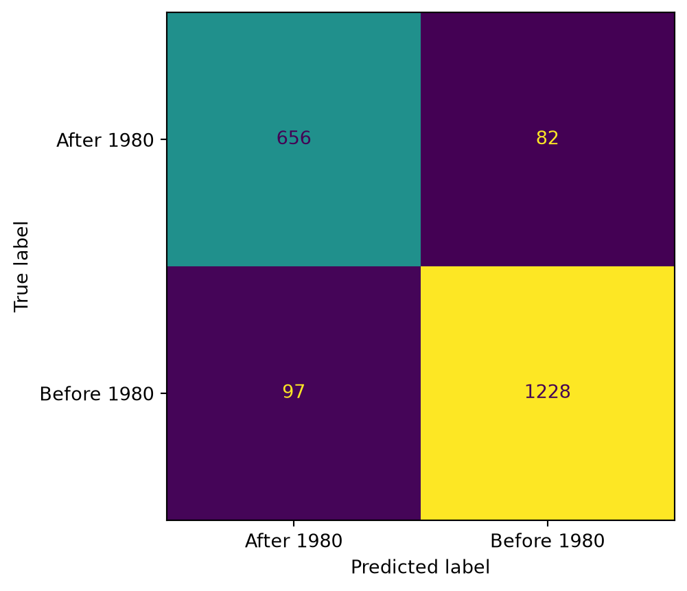

```python
from sklearn.metrics import recall_score, precision_score,confusion_matrix, ConfusionMatrixDisplay

recall = recall_score(y_test,predict)
precision = precision_score(y_test,predict)
print(f"Recall value: {(recall*100):.2f}%\tPrecision value: {(precision*100):.2f}%")
confusion = confusion_matrix(y_test,predict)
ConfusionMatrixDisplay(confusion_matrix=confusion,display_labels=['After 1980','Before 1980']).plot(
  colorbar=False
)
```